# Lecture 7

## Quantitative trait evolution

Now that we have a better feeling for how all of the different processes impact the evolution in alleles, it’s worth thinking about quantitative traits in general.

Today we’ll talk about how genetic variation for traits is distributed, and what this tells us about their evolution.

We’ll talk about how we can identify causal alleles for traits, and why sometimes that is either impossible, or extra complicated.

We’ll end by considering the *ultimate* trait - fitness, and how fitness changes as populations evovle (and what that can teach us about evolution of reproductive isolation, hybridization, etc.)

## Last time

Last week we talked about the Breeder’s equation.

$$R = S h^2 = S \frac{V_A}{V_P}$$

This equation describes how a trait changes based on changes in the average among those who mated vs the whole population, and how much of that change is heritable.

We did not discuss how $V_A$ changes in response to selection.

## Change in genetic variability due to selection

Let’s think through multiple cases:

Take directional selection, with all alleles being nice additive values for trait: decreases

Take directional selection, but all alleles are overdominant: decreases even faster.

Stabilizing selection, additive values: decreases as different alleles become fixed.

Stabilizing and overdominance: while no alleles are fixed, $V_A$ goes to 0.

## Remember that we care about the *additive* genetic variation

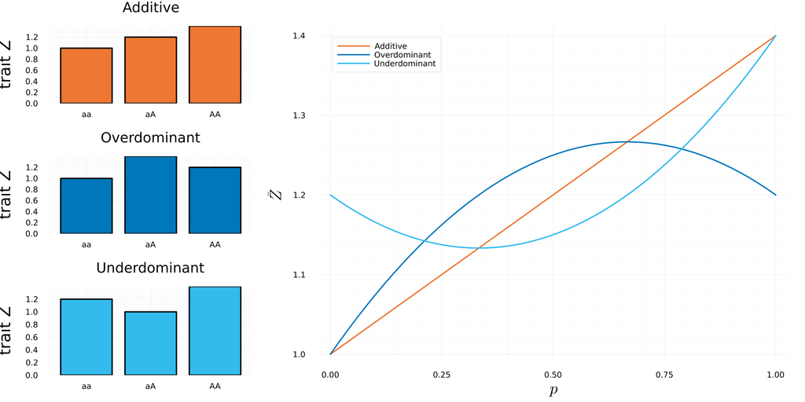

## Renewing $V_A$

Mutations re-introduce genetic variation for a trait.

Because they are *extremely* rare when they enter the population, most change in allele frequencies leads to additive effects.

So, most new mutations increase additive genetic variation for a trait.

Long-term - $V_A$ will settle on a value depending on both new mutations and strength of selection.

## Some counter-factuals

Just because genetic variation decreases due to selection, does not mean it disappears.

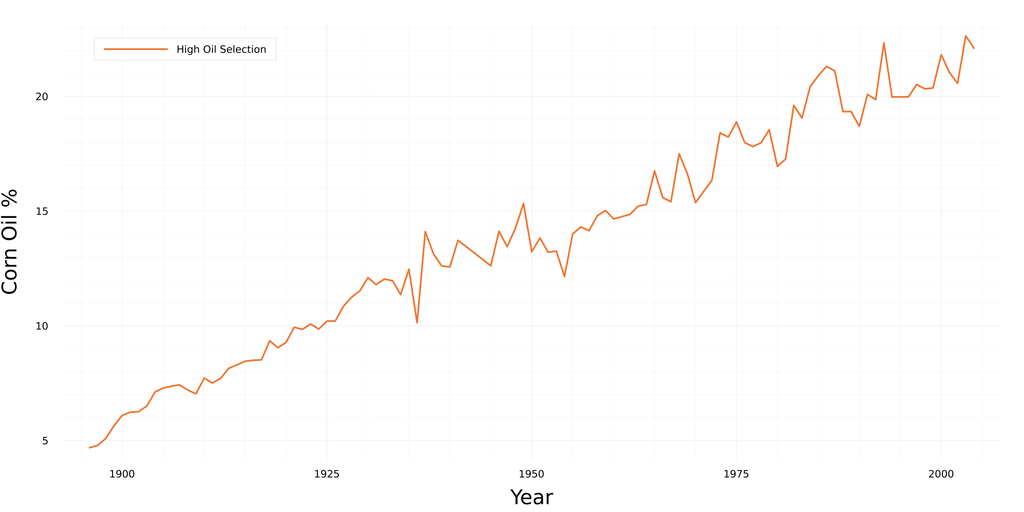

## But it *can* have limits

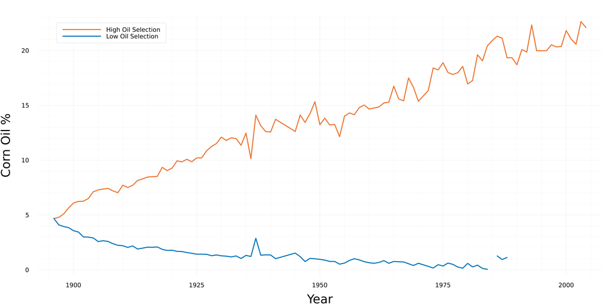

## But it *is* reversible

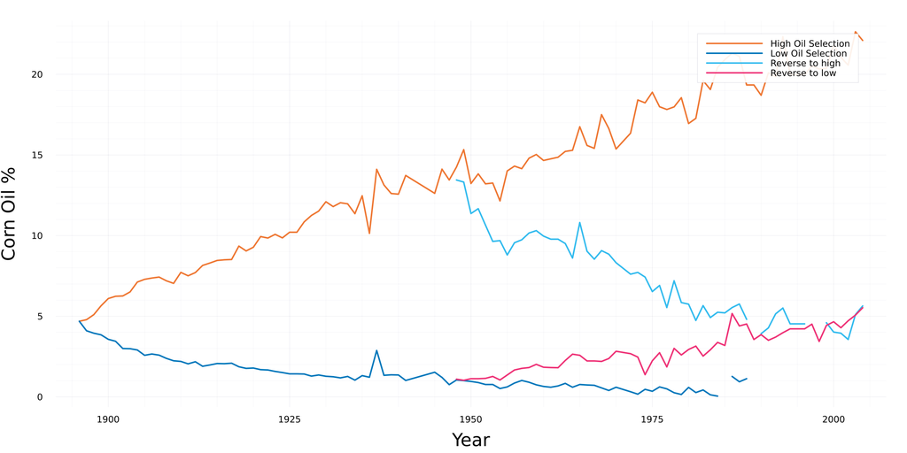

## Long term change re-measured

It’s worth considering that changing by 1% oil content may be much easier when oil content is high than when it is low.

We instead consider the $log(\frac{X_1}{X_2})$, where $X_1$ is the starting trait value, and $X_2$ is the ending one.

What’s often noticed on this scale is that change is *not* linear: change might be faster initially, and slow down later.

Not the case in corn data!

## In oil data

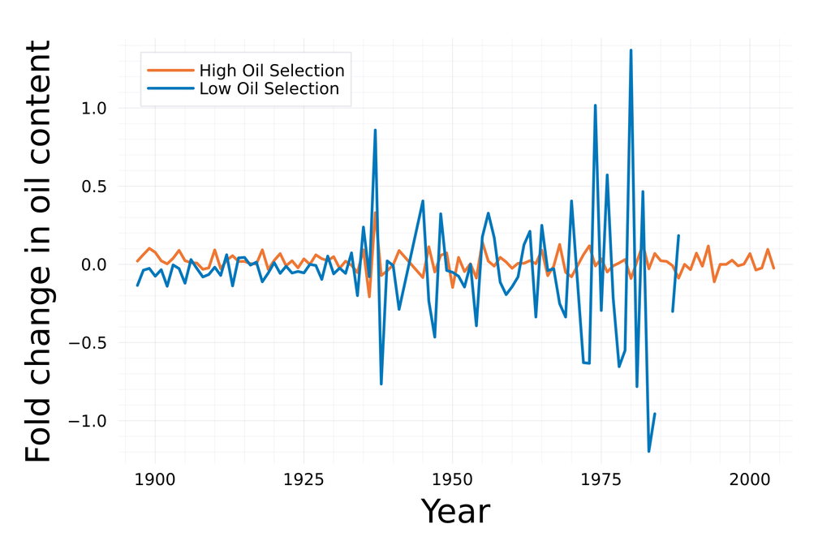

## LTEE of fitness

It *is* the case for change in fitness in Lenski’s long term *E. coli* evolution.

[figure not shown]

Why?

## Fisher’s Geometric Model

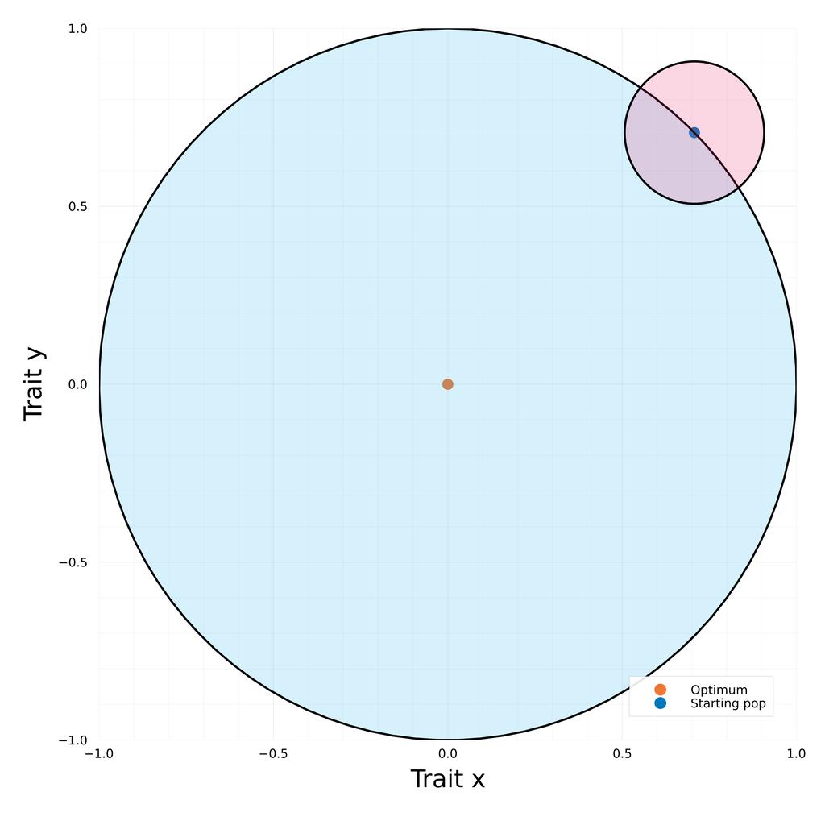

## When closer to optimum

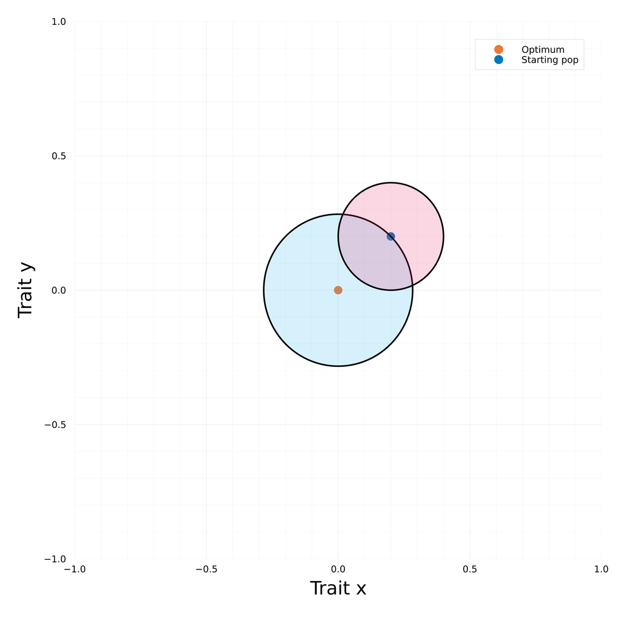

## When *really* close to optimum

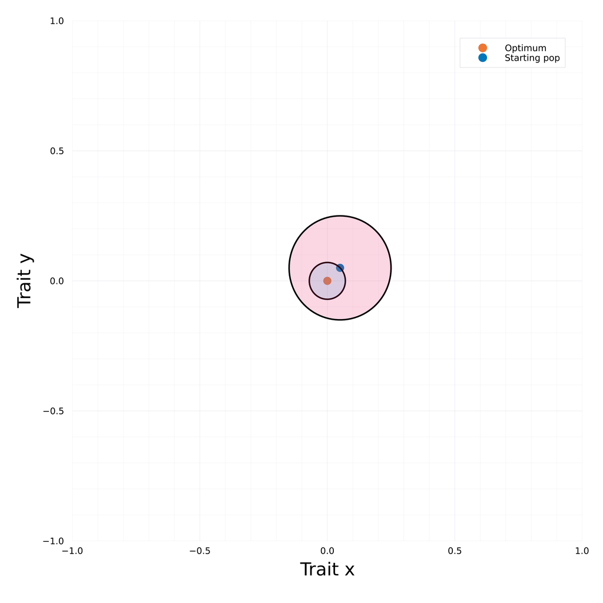

## So, expectation when adapting to new optimum

When populations adapt to a new optimum, the first fixed mutations are expected to have large effects.

Mutations fixed later in the process have increasingly smaller effects, as large effect mutations become increasingly likely to be deleterious.

Vanishingly unlikely that population ever fully adapts to optimum, and will instead reach a point where selection is about as strong as drift.

## How do we detect phenotypic selection?

Knowing if some traits are under directional or stabilizing selection might be important.

Could just compare many related species and see if your species of interest is “extreme” for a trait value.

The problem is that traits do no evolve independently - correlated change due to shared ancestry.

So, even if evolution is not directed, there may be differences along the phylogeny that look significant.

The whole field of phylogenetic comparative methods is there to help you.

## Phylogenetic comparative methods

Easiest to show the problem using multiple trait correlations.

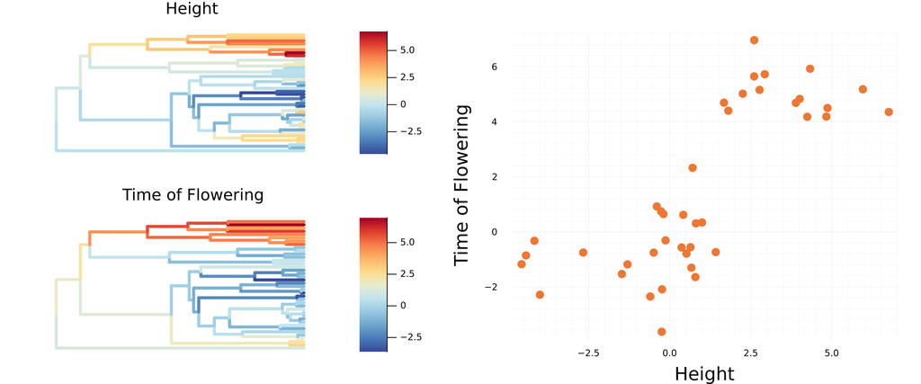

## PIC example

In this case - no actual correlation between traits (or directionality): both simulated under Brownian-Motion.

One simple way to account for shared history: Phylogenetically independent contrasts.

Calculate differences between each branch, and compare these.

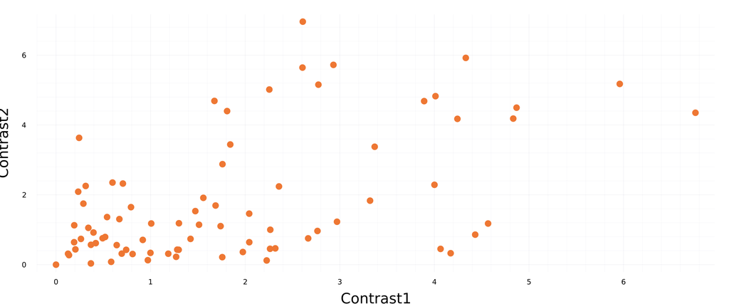

## Brownian motion as a null model

We can also use the expectations from Brownian motion to see if traits are evolving faster/slower than expected.

Ideally, we can identify rates across the tree, and find *rate shifts*: branches on which evolutionary rates have changed.

Without the evolutionary context - an extreme trait value could just be a result of drift

Especially true if trait is highly polygenic - lots of small random changes can lead to big overall differences.

## How can we identify genetic structure of traits?

Understanding the genetic basis of adaptive traits is not as straightforward as it may seem.

We covered this in part already - you can look at regions with differences between closely related species for selection, but not guaranteed to link to your trait.

If you can interbreed - QTL.

If still polymorphic - GWAS.

## Genome Wide Association Studies

Genome wide association studies essentially take genotypes of many individuals in a population along with their phenotypes, and return the correlation between each genotype and the phenotype of interest.

At its heart - simple linear regression!

More broadly - can take advantage of known inheritance patterns (pedigrees) to account for population structure.

## GWAS example

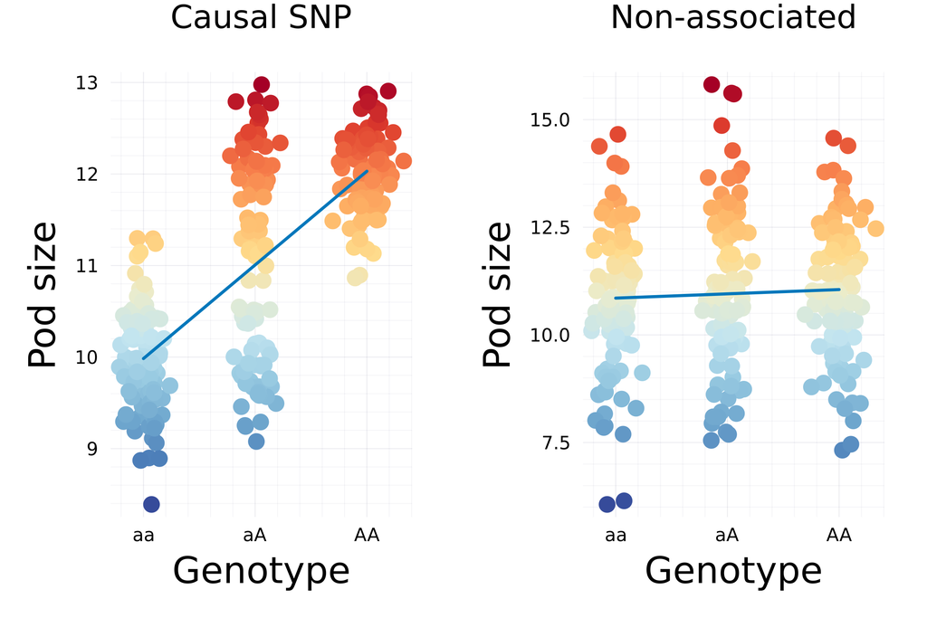

## Accounting for population structure

The problem with just running a linear model is that some correlations exist for other reasons.

LD with the actual causal locus.

Correlation with environmental explanatory variable.

## Back to example

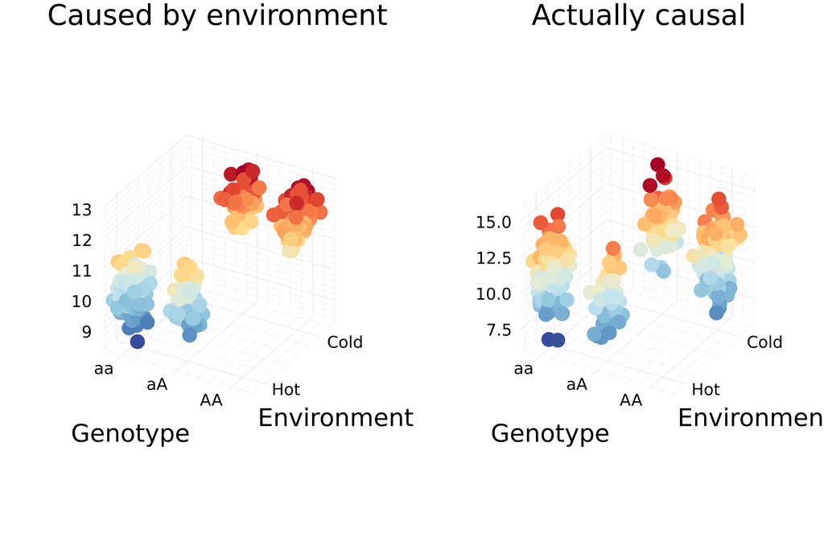

## More details

Most GWAS approaches are structured as linear mixed models:

$$z = x + C + \epsilon$$

Where $x$ is the genotype at a site, $C$ is a covariate matrix, and $\epsilon$ is noise.

For many analyses, the covariate will be the first few PCs of a PCA of the data. Why?

Ideally, these would be ancestry correlations, but as you’ve seen, these can be hard to estimate.

## Some things you can’t account for

Even when GWAS is performed *perfectly*, we can still have a lot of missing information.

“Missing heritability” in height. Height about 80% heritable in worst case.

Multiple issues: low power to detect effects of rare variants, correction for structure exclude GxE effects, etc.

Height is also a complex trait affected by many other selected traits (nutrition,immunity).

Predictions harder when there is multi-trait selection and alleles are pleiotropic.

## Multi-trait correlations and selection

We’ve covered the Breeder’s Equation, but an equally important result is Lande’s Multivariate Breeder’s Equation:

$$\Delta \bar{Z} = GP^{-1}S = G \beta$$

Here, $G$ is the genetic variance-covariance matrix, $P$ is the phenotypic covariance matrix and $S$ is the selection gradient. $\beta$ is the vector of directional selection gradients. $\beta$ is a fraction of the phenotypic variance that is selected.

## A quick example

$$\Delta \bar{Z} = \begin{bmatrix} 2 & 0.6 \\ 0.6 & 1 \end{bmatrix} \begin{bmatrix} 1 \\ -0.1 \end{bmatrix} \approxeq \begin{bmatrix} 2 \\ 1/2 \end{bmatrix}$$

## What does that mean

Traits change in proportion to genetic co-variation.

A trait can move in the opposite direction of its optimum, if selection on a different trait is stronger and correlations are strong.

Most famously: Darwin’s Finches

## Darwin’s Finches

Galapagos struck by a drought in 1976. Peter and Rosemary Grant measured ~700 finches before the drought, and kept track of survivors.

| Trait | Before drought average | After drought average |
| --- | --- | --- |
| Weight | 16.06 | 17.13 |
| Bill length | 10.63 | 10.95 |
| Bill depth | 9.21 | 9.70 |

From the first glance - looks like positive selection on all three traits.

If we account for genetic covariance in traits, we can calculate $\beta$.

## Inferred selection

| Trait | $\beta$ |
| --- | --- |
| Weight | 0.477 |
| Bill length | -0.144 |
| Bill depth | 0.528 |

Because bill length and depth are highly correlated, stronger selection wins out.

## Across species variation

[figure not shown]

Beausoleil et al. 2023

## Some fun thoughts

When we think about evolvability, we need to consider the mean of the population.

Even when multiple alternate strategies have are different fitness peaks with deep valleys between - the population may be able to contain both peaks.

Reproductive isolation due to alternate strategies requires the peaks to be far apart, or the valleys very deep.

## More consequences

Whether populations can evolve to different parts of a fitness landscape depends on *how* the traits are correlated.

[figure not shown]

example

## Visually:

Simulation courtesy of Diogo Melo:

[link](https://curso-genevol.shinyapps.io/superficie-adaptativa/)

## Consequences for interpreting data.

If a trait you are studying is controlled by many alleles, and is potentially linked to other traits under selection, inference of evolutionary patterns becomes increasingly difficult.

If the trait is highly polygenic, each individual allele might have low signal.

If the alleles controlling the trait are highly pleiotropic - signal may be dampened depending on how trait is measured.

If multiple traits genetically covariated and one under very strong selection - the other will have low polymorphism, so low power to detect causal alleles.

## The ultimate complex trait - fitness

We’ve already mentioned this, but fitness is a highly composite trait.

Likely affected to some degree by more or less every allele *and* tied to most traits.

Yet, we can often detect clear signals of adaptation, with alleles showing strong relationships w/fitness.

So, even when you study complex traits, you *can* identify the causal alleles. But optimal values may be harder to find.

## How common is this worry of complex genetic underpinnings of traits?

There are certainly some traits with simple genetic control (e.g. 1-2 alleles of strong effect).

The slowly building consensus is that many traits of interest may in fact be “omnigenic” - affected to some degree by pretty much any allele in the genome.

Most alleles either influence trait, or linked to something that does.

In practice, each location is at least somewhat correlated to any continuous trait of interest.

Data primarily coming from *D. melanogaster*, *S. cerevisiae* : large population sizes, rapid generation times, easy for a cell division rate to influence most traits.

Might not be the case for other organisms, especially with smaller pop sizes and longer generation times.

## Back to Speciation

Let’s consider for a moment two populations evolving to the *same* peak.

Even though they will both evolve similar trait values, *how* they control these traits may be different.

Simplest case: two traits, single optimum.

See chalkboard

## Speciation in Fisher’s Geometric Model

Fisher’s Geometric Model can generate some nice predictions about how fitness between different groups will change as they diverge, *even if they evolve to the same peak*.

Notably - fitness in hybrids will decrease because of different combinations of alleles shifting you off of the optimum.

Cool aspects: - Makes relatively simple assumptions about the fitness landscape - Generates some known patterns of speciation biology - Can be parameterized using known hybrid fitness data - Can explain hybrid speciation

Weaknesses: - Many more assumptions needed to get other classic results - Allows for heterosis, but only if parents are both unfit - Strong assumptions about the effect size of mutations, especially for some of the big results

## Alternatives to explain speciation

Bateson-Dobzhansky-Muller Incompatibilities!

More on this next week, as we chat about all of the processes interplaying with each other for changes in allele frequencies.

The week after, we’ll talk more about how the interplay of all of the processes results in trait evolution.

Finally, we’ll chat about the geneology of all alleles including all of these processes - the Ancestral Recombination Graph. We’ll discuss some approaches to estimating it, and what to do once you have it.

## Student’s Choice

The last two weeks we’ve reserved for student’s choice of topics.

I’ll send out a survey with several topics I would normally include but haven’t had the time for, but I’ll leave a blank for whatever your heart desires.

We’ll lock in favorite options next week.

Strong caveat - if it’s something I’ve never worked on, might not be as good of a lecture/lab.

## Paper for this week

Chen and Pannell - completely optional, but cool study.

Examine how the fitness of different plants changes as they produce varying amounts of male/female flowers.

The optimum is *not* to specialize in one or the other - indeed, the dynamics are quite complex.

Male flower production correlated with hermaphroditic flower production, so optimum becomes complex.

Further - self-fertilization can lead to inbreeding, so different optima depending on whether inbreeding is considered or ignored.